# SBM for Topic Modeling

How to fit a stochastic block model for topic modeling.

## We need some packages

```python
%load_ext autoreload
%autoreload 2

import os
import numpy as np
import pylab as plt
%matplotlib inline

import graph_tool.all as gt
import sbmtm as sbmtm
```

# Look at some texts

1) We have a list of documents, each document contains a list of word-tokens.

2) We have a list of document titles (optional)

```python
path_data = ''

## texts
fname_data = 'corpus.txt'
filename = os.path.join(path_data,fname_data)

with open(filename,'r') as f:
    x = f.readlines()
texts = [h.split() for h in x]

## titles
fname_data = 'titles.txt'
filename = os.path.join(path_data,fname_data)

with open(filename,'r') as f:
    x = f.readlines()
titles = [h.split()[0] for h in x]
```

```python
titles[0],texts[0][:10]
```

```
('Nuclear_Overhauser_effect',
 ['the',
  'nuclear',
  'overhauser',
  'effect',
  'noe',
  'is',
  'the',
  'transfer',
  'of',
  'nuclear'])
```

# Make a bipartite word-document network in graph-tool

We represent the occurrences of words in documents as an undirected, bipartite, multigraph.

Given d=1,...,D documents and w=1,...,V word-types (vocabulary) and N words in total, we obtain a graph with n=1,...,D+V nodes and N edges. The first D nodes (n=1,...,D) will be document-nodes ('kind'=0) and the remaining V nodes (n=D+1,...,D+V) will be word-nodes ('kind'=1).

```python
g = sbmtm.make_graph(texts,documents=titles)
g
```

```
<Graph object, undirected, with 3203 vertices and 39704 edges at 0x7facfe4e1438>
```

# Doing Inference

Find groups (or communities) in the network.

Since we have a bipartite network, the $V$ word-nodes will be clustered into $Bw$ word-groups, and the $D$ document-nodes will be clustered into $Bd$ document-groups, such that we get $B = Bd+Bw$ groups in total.

Furthermore, we will fit a hierarchical model, such that we obtain this group structure on $L$ levels of increasing granularity --- until we end up with 1 trivial group containing all nodes.

Note that the number of levels in the hierarchy, $L$, and the number of groups $Bd$ and $Bd$ (on each level of the hierarchy) are determined automatically.

```python
## result is a dictioanry containing all the results from fitting the SBM
result = sbmtm.sbm_fit(g)
```

# Plotting the result

We show the bipartite network:

- document-nodes on the left
- word-nodes on the right

Different colors correspond to the different groups.

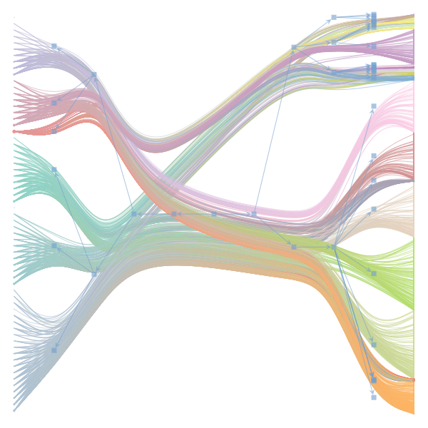

```python
pedges = 0.05 ## subsample the number of edges
filename_save = None# "draw_hierarchy.pdf" ## filename to save the plot/ None for not saving
sbmtm.sbm_plot(result,pedges=pedges,filename_save=filename_save)
```

# A detailed look at the inferred groups

First we have to specify a level in the hierarchy

```python
L = result['L'] ## number of levels, l=0,1,...,L-1
l = 1 ## l=L-1 corresponds to the trivial level: all nodes in the same group

## the number of groups on that level
Bd,Bw = sbmtm.get_Bwd(result,l)


print('Number of levels: ',L)
print('Number of doc-groups on level %s: %s'%(l,Bd))
print('Number of word-groups on level %s: %s'%(l,Bw))
```

```
Number of levels:  5
Number of doc-groups on level 1: 2
Number of word-groups on level 1: 4
```

# Most common words and documents

## The most common words in the word-groups

```python
dict_words = sbmtm.most_common_words(result,l)
dict_words
```

```
{0: [('the', 0.10063526007925026),
  ('of', 0.05679602490722687),
  ('and', 0.035285238065287126),
  ('a', 0.03295804767595446),
  ('to', 0.03195169507516196),
  ('in', 0.030788099880495627),
  ('is', 0.02550474872633499),
  ('for', 0.013459966035599723),
  ('as', 0.012547958991131519),
  ('that', 0.010157871564249323)],
 1: [('s', 0.05243764172335601),
  ('at', 0.045351473922902494),
  ('data', 0.02465986394557823),
  ('its', 0.02295918367346939),
  ('first', 0.022675736961451247),
  ('structure', 0.022108843537414966),
  ('molecular', 0.021825396825396824),
  ('energy', 0.01927437641723356),
  ('if', 0.01870748299319728),
  ('analysis', 0.018424036281179137)],
 2: [('formula', 0.17012779552715654),
  ('law', 0.04552715654952077),
  ('force', 0.038338658146964855),
  ('uncertainty', 0.037539936102236424),
  ('spin', 0.037539936102236424),
  ('surface', 0.036741214057507986),
  ('newton', 0.034345047923322686),
  ('magnetic', 0.03274760383386582),
  ('body', 0.03274760383386582),
  ('frequency', 0.03035143769968051)],
 3: [('folding', 0.0508637236084453),
  ('protein', 0.044465770953294945),
  ('home', 0.04062699936020473),
  ('computational', 0.024632117722328855),
  ('bioinformatics', 0.023352527191298784),
  ('research', 0.02111324376199616),
  ('biology', 0.016314779270633396),
  ('sequence', 0.015035188739603326),
  ('proteins', 0.01471529110684581),
  ('project', 0.013115802943058221)]}
```

## The documents with largest probability for each document-group

```python
dict_docs = sbmtm.most_common_docs(result,l)
dict_docs
```

```
{0: [('Wave_tank', 1.0),
  ('Elevator_paradox_(physics)', 1.0),
  ('Experimental_physics', 1.0),
  ('Particle-induced_X-ray_emission', 1.0),
  ('Ripple_tank', 1.0),
  ('Uncertainty', 1.0),
  ("Newton's_laws_of_motion", 1.0),
  ('Pauli_effect', 1.0),
  ('Empirical_formula', 1.0),
  ('Ziff-Gulari-Barshad_model', 1.0)],
 1: [('De_novo_transcriptome_assembly', 1.0),
  ('Premier_Biosoft', 1.0),
  ('BioUML', 1.0),
  ('List_of_Directors_General_of_CERN', 1.0),
  ('Fragment_separator', 1.0),
  ('Bioinformatics', 1.0),
  ('Computational_biology', 1.0),
  ('Folding@home', 1.0),
  ('K-mer', 1.0),
  ('Journal_of_Computational_Biology', 1.0)]}
```

# Group membership distributions

### Document group membership

p_td_d is an array of shape B_d x D

- the first index refers to the doc-group
- the second index refers to the documents (see 'docs')

### Word group membership

p_tw_w is an array of shape B_w x V

- the first index refers to the word-group
- the second index refers to the words (see 'words')

Note that we are considering a non-overlapping stochastic blockmodel. Therefore, each node (word or document) can belongs to one and only one group.

```python
p_td_d,p_tw_w = sbmtm.sbm_group_membership(result,l)
words = result['words']
docs = result['docs']
```

```
Text(0,0.5,'doc-group $t^{(d)}$')
```

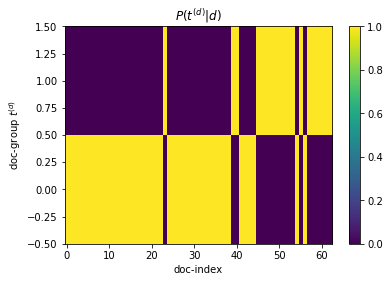

```python
## the group-membership of each doc-group
plt.imshow(p_td_d,aspect='auto',origin='lower')
plt.colorbar()
plt.title(r'$ P( t^{(d)} | d ) $')
plt.xlabel('doc-index')
plt.ylabel(r'doc-group $t^{(d)}$')
```

```
Text(0,0.5,'word-group $t^{(w)}$')
```

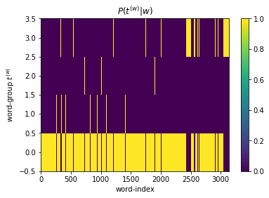

```python
## the group-membership of each word-group
plt.imshow(p_tw_w,aspect='auto',origin='lower')
plt.colorbar()
plt.title(r'$ P( t^{(w)} | w ) $')
plt.xlabel('word-index')
plt.ylabel(r'word-group $t^{(w)}$')
```

# Topic distributions

## What are the topics: P( w | tw )

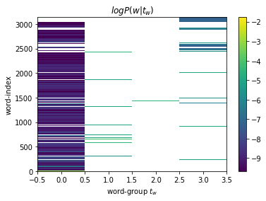

```python
p_w_tw = sbmtm.sbm_topicdist_w(result,l)
plt.imshow(np.log(p_w_tw),aspect='auto',origin='lower')
plt.title(r'$log P( w | t_w ) $')
plt.xlabel(r'word-group $t_w$')
plt.ylabel('word-index')
plt.colorbar()
```

## How are the topics mixed in the documents: P( tw | d )

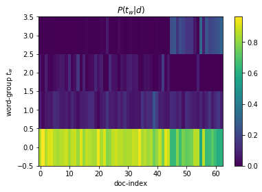

```python
## Mixture of word-groups into documetns
## P(t_w | d)

p_tw_d = sbmtm.sbm_topicdist_d(result,l)
plt.imshow(p_tw_d,aspect='auto',origin='lower')
plt.title(r'$ P( t_w | d ) $')
plt.xlabel('doc-index')
plt.ylabel(r'word-group $t_w$')
plt.colorbar()
```